# jumeg_filtering

## Filtering in jumeg

### Comparison of the various filters availables for use in mne/jumeg

```python
%matplotlib inline
```

```python
import numpy as np
import matplotlib.pyplot as plt

import mne
from mne.datasets import sample

data_path = sample.data_path()
raw_fname = data_path + '/MEG/sample/sample_audvis_raw.fif'

# load the raw data
raw = mne.io.Raw(raw_fname, preload=True)
picks = mne.pick_types(raw.info, meg='mag', exclude='bads')
print('Sampling frequency is %f' % raw.info['sfreq'])
```

```
Opening raw data file /Users/psripad/mne_data/MNE-sample-data/MEG/sample/sample_audvis_raw.fif...
    Read a total of 3 projection items:
        PCA-v1 (1 x 102)  idle
        PCA-v2 (1 x 102)  idle
        PCA-v3 (1 x 102)  idle
    Range : 25800 ... 192599 =     42.956 ...   320.670 secs
Ready.
Current compensation grade : 0
Reading 0 ... 166799  =      0.000 ...   277.714 secs...
Sampling frequency is 600.614990
```

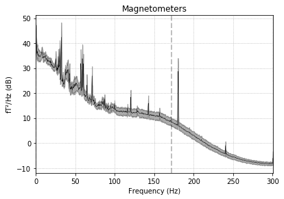

```python
# plot the raw psd
raw.plot_psd(tmin=0.0, tmax=160., fmin=0, fmax=np.inf, n_fft=None,
             picks=picks, ax=None, color='black', area_mode='std',
             area_alpha=0.33, n_overlap=0, dB=True, average=True,
             show=True, n_jobs=4, line_alpha=None,
             spatial_colors=None, xscale='linear', verbose='ERROR');
```

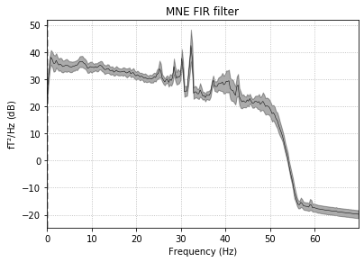

```python
# filter data using mne filter_data
# (mne.filter.band_pass_filter, jumeg.jumeg_preprocessing.apply_filter all use the same underlying function)

l_freq, h_freq = 1., 45.
fir_filt = raw.copy().filter(l_freq, h_freq, picks=picks, filter_length='auto',
                             l_trans_bandwidth='auto', h_trans_bandwidth='auto',
                             n_jobs=4, method='fir', iir_params=None, phase='zero',
                             fir_window='hamming', verbose='ERROR')

# plot the FIR filtered raw psd
fig = fir_filt.plot_psd(tmin=0.0, tmax=160., fmin=0, fmax=70., n_fft=None,
                  picks=picks, ax=None, color='black', area_mode='std',
                  area_alpha=0.33, n_overlap=0, dB=True, average=True,
                  show=False, n_jobs=4, line_alpha=None,
                  spatial_colors=None, xscale='linear', verbose='ERROR');
fig.gca().set_title('MNE FIR filter');
```

[figure not shown]

```python
filter_type = 'butter'
filt_method = 'fft'
iir_params={'ftype': filter_type, 'order': 4}

# apply IIR filter
iir_filt = raw.copy().filter(l_freq, h_freq, picks=picks, filter_length='auto',
                             l_trans_bandwidth='auto', h_trans_bandwidth='auto',
                             n_jobs=4, method='iir', iir_params=iir_params, phase='zero',
                             fir_window='hamming', verbose='ERROR')

# plot the IIR filtered raw psd
fig = iir_filt.plot_psd(tmin=0.0, tmax=160., fmin=l_freq, fmax=h_freq, n_fft=None,
                  picks=picks, ax=None, color='black', area_mode='std',
                  area_alpha=0.33, n_overlap=0, dB=True, average=True,
                  show=False, n_jobs=4, line_alpha=None,
                  spatial_colors=None, xscale='linear', verbose='ERROR');
fig.gca().set_title('MNE BW IIR filter');
```

```python
from jumeg.filter import jumeg_filter
```

```
Effective window size : 3.410 (s)
```

```
[Parallel(n_jobs=4)]: Using backend LokyBackend with 4 concurrent workers.
[Parallel(n_jobs=4)]: Done   2 out of   4 | elapsed:    0.4s remaining:    0.4s
[Parallel(n_jobs=4)]: Done   4 out of   4 | elapsed:    0.7s remaining:    0.0s
[Parallel(n_jobs=4)]: Done   4 out of   4 | elapsed:    0.7s finished
```

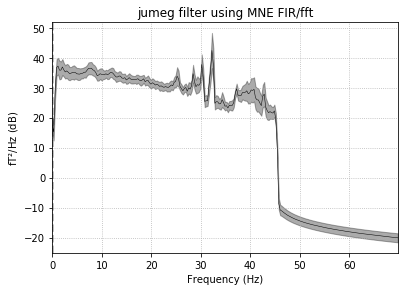

```python
# apply the jumeg filter using mne (just to check)
filt_ju_mne = jumeg_filter(filter_method='mne', filter_type='bp', fcut1=l_freq, fcut2=h_freq,
                           remove_dcoffset=True, sampling_frequency=raw.info['sfreq'],
                           filter_window='hamming', notch=np.array([50., 60.]), notch_width=1.0, order=4, njobs=4,
                           mne_filter_method='fft',mne_filter_length='10s',trans_bandwith=0.5)
ju_mne_filt = raw.copy()  # make a copy
ju_mne_filt._data = filt_ju_mne.apply_filter(ju_mne_filt._data, picks)

# plot the jumeg MNE filtered raw psd
fig = ju_mne_filt.plot_psd(tmin=0.0, tmax=160., fmin=0, fmax=70., n_fft=None,
                     picks=picks, ax=None, color='black', area_mode='std',
                     area_alpha=0.33, n_overlap=0, dB=True, average=True,
                     show=False, n_jobs=4, line_alpha=None,
                     spatial_colors=None, xscale='linear', verbose=None);
fig.gca().set_title('jumeg filter using MNE FIR/fft');
```

```
Effective window size : 3.410 (s)
```

```
[Parallel(n_jobs=4)]: Using backend LokyBackend with 4 concurrent workers.
[Parallel(n_jobs=4)]: Done   2 out of   4 | elapsed:    1.2s remaining:    1.2s
[Parallel(n_jobs=4)]: Done   4 out of   4 | elapsed:    2.1s remaining:    0.0s
[Parallel(n_jobs=4)]: Done   4 out of   4 | elapsed:    2.1s finished
```

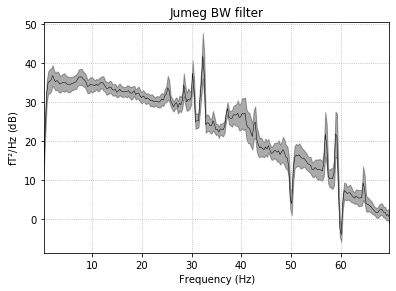

```python
# apply the jumeg filter using bw
filt_ju_bw = jumeg_filter(filter_method="bw", filter_type='bp', fcut1=l_freq, fcut2=h_freq,
                          remove_dcoffset=True, sampling_frequency=raw.info['sfreq'],
                          filter_window='hamming', notch=np.array([50., 60.]), notch_width=1.0, order=4, njobs=4,
                          mne_filter_method='fft',mne_filter_length='10s',trans_bandwith=0.5)
filt_ju_bw.verbose = False
ju_bw_filt = raw.copy()  # make a copy
filt_ju_bw.apply_filter(ju_bw_filt._data, picks)

# plot the jumeg MNE filtered raw psd
fig = ju_bw_filt.plot_psd(tmin=0.0, tmax=160., fmin=0.1, fmax=70., n_fft=None,
                    picks=picks, ax=None, color='black', area_mode='std',
                    area_alpha=0.33, n_overlap=0, dB=True, average=True,
                    show=False, n_jobs=4, line_alpha=None,
                    spatial_colors=None, xscale='linear', verbose=None);
fig.gca().set_title('Jumeg BW filter');
```

```python
print(filt_ju_bw.filter_name_postfix)
```

```
fibp1-45n2
```

[output not shown]

```
[Parallel(n_jobs=4)]: Using backend LokyBackend with 4 concurrent workers.
[Parallel(n_jobs=4)]: Done   2 out of   4 | elapsed:    0.5s remaining:    0.5s
[Parallel(n_jobs=4)]: Done   4 out of   4 | elapsed:    0.7s remaining:    0.0s
[Parallel(n_jobs=4)]: Done   4 out of   4 | elapsed:    0.7s finished
```

[figure not shown]

```python
## plot the window sinc filter results also
# from jumeg.filter.jumeg_filter_ws import JuMEG_Filter_Ws
# filt_ju_ws = jumeg_filter(filter_method='ws', filter_type='bp', fcut1=l_freq, fcut2=h_freq,
#                           remove_dcoffset=True, sampling_frequency=raw.info['sfreq'],
#                           filter_window='hamming', notch=np.array([50., 60.]), notch_width=1.0, order=4, njobs=4,
#                           mne_filter_method='fft',mne_filter_length='10s',trans_bandwith=0.5)

# ju_ws_filt = raw.copy()  # make a copy
# ju_ws_filt.notch_filter(np.array([50., 60.]), picks=picks, filter_length='auto',
#                         notch_widths=None, trans_bandwidth=1.0, n_jobs=1, method='fir',
#                         iir_params=None, mt_bandwidth=None, p_value=0.05, phase='zero',
#                         fir_window='hamming', verbose=None)

# filt_ju_ws.apply_filter(ju_ws_filt._data, picks)

## plot the jumeg Window Sinc filtered raw psd
# fig = ju_ws_filt.plot_psd(tmin=0.0, tmax=160., fmin=0, fmax=70., n_fft=None,
#                     picks=picks, ax=None, color='black', area_mode='std',
#                     area_alpha=0.33, n_overlap=0, dB=True, average=True,
#                     show=False, n_jobs=4, line_alpha=None,
#                     spatial_colors=None, xscale='linear', verbose=None);
# fig.gca().set_title('Jumeg Window Sinc filter');
```

```
Effective window size : 3.410 (s)
```

```
[Parallel(n_jobs=4)]: Using backend LokyBackend with 4 concurrent workers.
[Parallel(n_jobs=4)]: Done   2 out of   4 | elapsed:    1.1s remaining:    1.1s
```

```
Effective window size : 3.410 (s)
```

```
[Parallel(n_jobs=4)]: Done   4 out of   4 | elapsed:    2.1s remaining:    0.0s
[Parallel(n_jobs=4)]: Done   4 out of   4 | elapsed:    2.1s finished
[Parallel(n_jobs=4)]: Using backend LokyBackend with 4 concurrent workers.
[Parallel(n_jobs=4)]: Done   2 out of   4 | elapsed:    1.5s remaining:    1.5s
[Parallel(n_jobs=4)]: Done   4 out of   4 | elapsed:    3.3s remaining:    0.0s
[Parallel(n_jobs=4)]: Done   4 out of   4 | elapsed:    3.3s finished
```

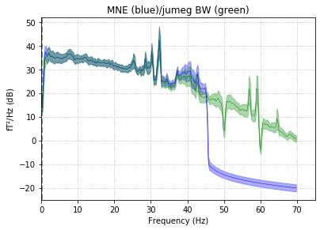

```python
plt.close()

fig, ax1 = plt.subplots(1, 1)

# plot the jumeg MNE filtered raw psd
ju_mne_filt.plot_psd(tmin=0.0, tmax=160., fmin=0, fmax=70., n_fft=None,
                     picks=picks, ax=ax1, color='blue', area_mode='std',
                     area_alpha=0.33, n_overlap=0, dB=True, average=True,
                     show=False, n_jobs=4, line_alpha=None,
                     spatial_colors=None, xscale='linear', verbose=None);

# plot the jumeg Butterworth filtered raw psd
ju_bw_filt.plot_psd(tmin=0.0, tmax=160., fmin=0, fmax=70., n_fft=None,
                    picks=picks, ax=ax1, color='green', area_mode='std',
                    area_alpha=0.33, n_overlap=0, dB=True, average=True,
                    show=False, n_jobs=4, line_alpha=None,
                    spatial_colors=None, xscale='linear', verbose=None);

# # plot the jumeg Windowsinc filtered raw psd
# fig = ju_ws_filt.plot_psd(tmin=0.0, tmax=160., fmin=0, fmax=70., n_fft=None,
#                     picks=picks, ax=ax1, color='red', area_mode='std',
#                     area_alpha=0.33, n_overlap=0, dB=True, average=True,
#                     show=True, n_jobs=4, line_alpha=None,
#                     spatial_colors=None, xscale='linear', verbose=None);

ax1.set_xlim(0., 75.);
ax1.set_title('MNE (blue)/jumeg BW (green)');
```

- The mne filter uses filter_data routine to perform band pass filtering and the notch_filter routine to perform notch filtering.
- MNE filter with FIR filtering performs better than using an IIR Butterworth filter with oder 4.
- Jumeg filter module has three filters implemented
  - MNE filter (which wraps around MNE modules) (can be combined with notch filters)
  - jumeg Window Sinc filter (WS) (notch filter combination not implemented)
  - jumeg Butterworth filter (BW) (can be combined with notch filters)
- Of all the three jumeg implementations above, mne FIR filter shows the best performance.
- The WS implementation performs better than the jumeg BW (with order 4).

Recommendation: Presently, it is best to use the MNE FIR filter for our filtering requirements. The jumeg filter module (which wraps around mne filter) may be used when the MNE band_pass_filter needs to be combined with the notch_filter. In cases where the notch frequencies are removed using the noise reducer, the mne FIR filter can be directly used.